# Water Quality

## Introduction

Arsenic naturally occurs in groundwater sources around the world. Arsenic contamination of groundwater affects millions of people around the world including the United States, Nicaragua, Argentina, China, Mexico, Chile, Bangladesh, India, and Vietnam, for example (Smith et al. 2000; Amini et al. 2008; Lin et al. 2017). The World Health Organization (WHO 2018a) estimates that over 140 million people in 50 countries are exposed to arsenic contaminated drinking water above the WHO guideline of 10 $\mu$g/L. Health effects of arsenic exposure include numerous types of cancer and other disorders.

This project follows an analysis of a public health study performed in rural Bangladesh (Gelman et al. 2004). In this study, wells used for drinking water were analyzed for arsenic contamination and correspondingly labeled as safe or unsafe. The study determined whether households switched the well used for drinking water and measured. Additionally, several variables where measured that were thought to possibly influence the decision of whether or not to switch wells. Here, we will investigate how accurately we can predict whether or not a household will switch wells based on these environmental variables.

## Data Collection

See Gelman et al. (2004) for a discussion of data collection. Briefly, arsenic levels were measured in Araihazar, Bangladesh during the years 1999 - 2000. Additional information was collected by a survey: 1. Whether or not the household swithed wells. 2. The distance (in meters) to the closest known safe well. 3. Whether any members of the household are involved in community organizations. 4. The highest education level in the household.

### Load necessary packages

```r
#skimr provides a nice summary of a data set
library(skimr)
#tidyverse contains packages we will use for processing and plotting data
library(tidyverse)
#GGally has a nice pairs plotting function
library(GGally)
#tidymodels has a nice workflow for many models. We will use it for XGBoost
library(tidymodels)
#xgboost lets us fit XGBoost models
library(xgboost)
#vip is used to visualize the importance of predicts in XGBoost models
library(vip)
#Set the plotting theme
theme_set(theme_bw())
```

### Data ethics

#### The problem

Is it possible to answer our question with data? Is the problem well-posed?

Our main question for this assingment is: How accurately can we predict that a household will switch well after creating different models using our variables.

Can we cause harm to individuals with this project?

This project could potentially cause harm under the following instances:

1. The data was not ethically sourced
2. Our project is used to make false claims despite our best intentions

#### The data

##### Are individuals identified in the data set?

No, the data is anonimized.

##### Are there issues of privacy or consent that we should address?

I do not belive so no. Anonimizing the data makes it difficult to trace who said what.

##### Are there sources of bias in the data?

This data is mostly fact (distance to a well) with some survey questions.

I would have to see the way that questions were worded exactly but as of now I have no reason to believe that there are sources of bias in our data.

## Data Preparation

### Load the data

$\rightarrow$ Load the data set contained in the file `wells.dat` and name the data frame `df`.

```r
df <- read.table('/home/eddieavendano/Documents/GitHub/Spring-2021/Data-Science/water-quality/wells.dat')
```

### Explore the contents of the data set

```r
head(df)
```

```
##   switch arsenic   dist assoc educ
## 1      1    2.36 16.826     0    0
## 2      1    0.71 47.322     0    0
## 3      0    2.07 20.967     0   10
## 4      1    1.15 21.486     0   12
## 5      1    1.10 40.874     1   14
## 6      1    3.90 69.518     1    9
```

```r
# distance is in meters!, that info is from paper
```

#### Explore the columns

$\rightarrow$ What are the variables?

The variables are:

switch: An indicator of whether a household switches wells.

arsenic: The arsenic level of the household’s well.

dist: The distance (in meters) to the closest known safe well.

assoc: An indicator of whether any members of the household are involved in community organizations.

educ: The highest education level in the household.

$\rightarrow$ What variable(s) do we want to predict?

We are attempting to predict the switch variable

$\rightarrow$ What variables are possible predictors?

- arsenic
- dist
- assoc
- educ

are all possible predictors

#### Rename the columns

The names of the columns in this data frame are understandable, but two of the columns, `switch` and `distance`, have the names of functions that already exist in R. It is bad practice to name your variables or functions after existing functions, so we will change them. While we are at it, we will change some other names to be complete words.

```r
df <- df %>%
  rename(switch_well = "switch",
         distance = "dist",
         association = "assoc",
         education = "educ")
```

```r
head(df)
```

```
##   switch_well arsenic distance association education
## 1           1    2.36   16.826           0         0
## 2           1    0.71   47.322           0         0
## 3           0    2.07   20.967           0        10
## 4           1    1.15   21.486           0        12
## 5           1    1.10   40.874           1        14
## 6           1    3.90   69.518           1         9
```

### Further exploration of basic properties

switch: An indicator of whether a household switches wells.

arsenic: The arsenic level of the household’s well.

dist: The distance (in meters) to the closest known safe well.

assoc: An indicator of whether any members of the household are involved in community organizations.

In a tidy data set, each column is a variable or id and each row is an observation.

Each column is a variable while each row is an observation, thus the dataframe is tidy.

$\rightarrow$ How many observations are in the data set? How many missing values are there in each column?

```r
skim_without_charts(df)
```

Data summary

| Name | df |
| --- | --- |
| Number of rows | 3020 |
| Number of columns | 5 |
| _______________________ |  |
| Column type frequency: |  |
| numeric | 5 |
| ________________________ |  |
| Group variables | None |

**Variable type: numeric**

| skim_variable | n_missing | complete_rate | mean | sd | p0 | p25 | p50 | p75 | p100 |
| --- | --- | --- | --- | --- | --- | --- | --- | --- | --- |
| switch_well | 0 | 1 | 0.58 | 0.49 | 0.00 | 0.00 | 1.00 | 1.00 | 1.00 |
| arsenic | 0 | 1 | 1.66 | 1.11 | 0.51 | 0.82 | 1.30 | 2.20 | 9.65 |
| distance | 0 | 1 | 48.33 | 38.48 | 0.39 | 21.12 | 36.76 | 64.04 | 339.53 |
| association | 0 | 1 | 0.42 | 0.49 | 0.00 | 0.00 | 0.00 | 1.00 | 1.00 |
| education | 0 | 1 | 4.83 | 4.02 | 0.00 | 0.00 | 5.00 | 8.00 | 17.00 |

3020 observations, 0 missing

Note that all variables are coded as numeric variables, but `switch_well` and `association` are categorical variables that happen to be coded using 0 and 1. We will convert these variables to factors.

#### Convert data types for qualitative predictor

$\rightarrow$ Use the `mutate` function to convert `switch_well` and `association` to factors.

```r
df <- df %>%
  # mutating association from number to factor
  mutate(association = factor(association)) %>%
  # mutating swithc_well from number to factor
  mutate(switch_well = factor(switch_well))
```

```r
head(df)
```

```
##   switch_well arsenic distance association education
## 1           1    2.36   16.826           0         0
## 2           1    0.71   47.322           0         0
## 3           0    2.07   20.967           0        10
## 4           1    1.15   21.486           0        12
## 5           1    1.10   40.874           1        14
## 6           1    3.90   69.518           1         9
```

## Exploratory data analysis

We have two main goals when doing exploratory data analysis. The first is that we want to understand the data set more completely. The second goal is to explore relationships between the variables to help guide the modeling process to answer our specific question.

### Numerical summaries

$\rightarrow$ What are the ranges of each of the numerical variables? Are the counts of households that switch wells and do not switch wells balanced or unbalanced? That is, do we have roughly equal numbers of households that switch wells and do not switch wells?

```
                                 mean    sd      min     max
```

57.5% switched 42.5% did not switch

### Graphical summaries

$\rightarrow$ Use a pairs-plot to investigate the distributions of the variables and relationships between variables. Consider the following questions:

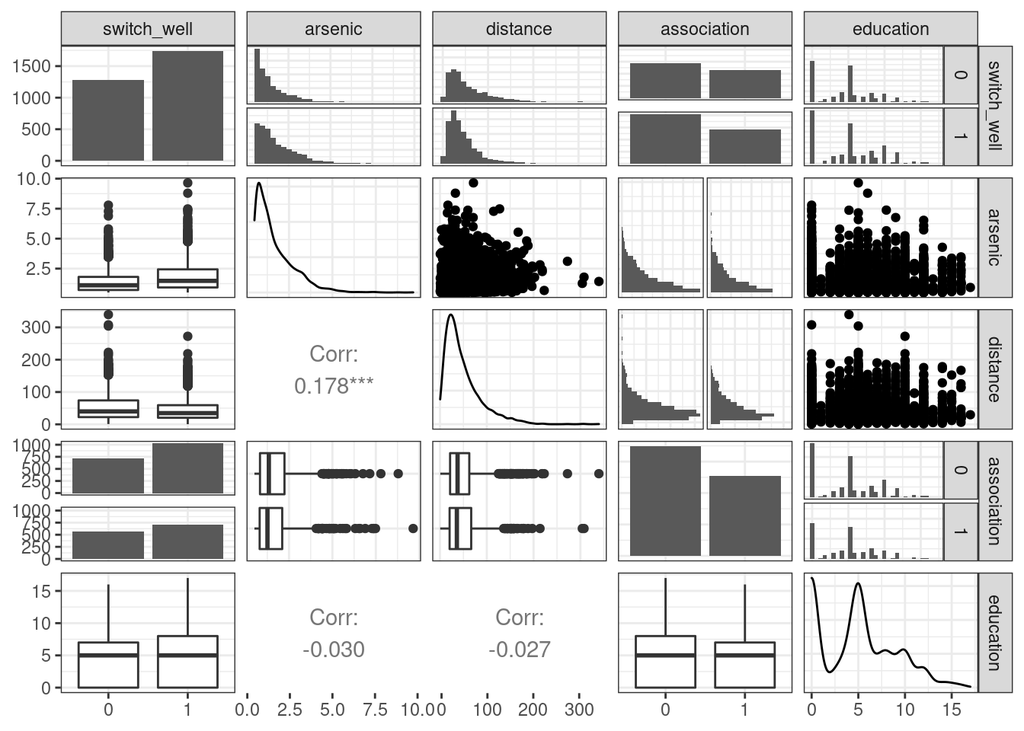

```r
# ggpairs creates pairplots
ggpairs(df,lower = list(continuous = "cor", combo = "box_no_facet", discrete ="facetbar", na = "na"), upper = list(continuous = "points", combo ="facethist", discrete = "facetbar", na = "na"), progress = FALSE)
```

1. What is the shape of the distribution of the numerical variables?

our numerical variables appear to be mostly right skewed

2. Do the predictor variables have different distributions for households that switch_well and do not switch_well wells?

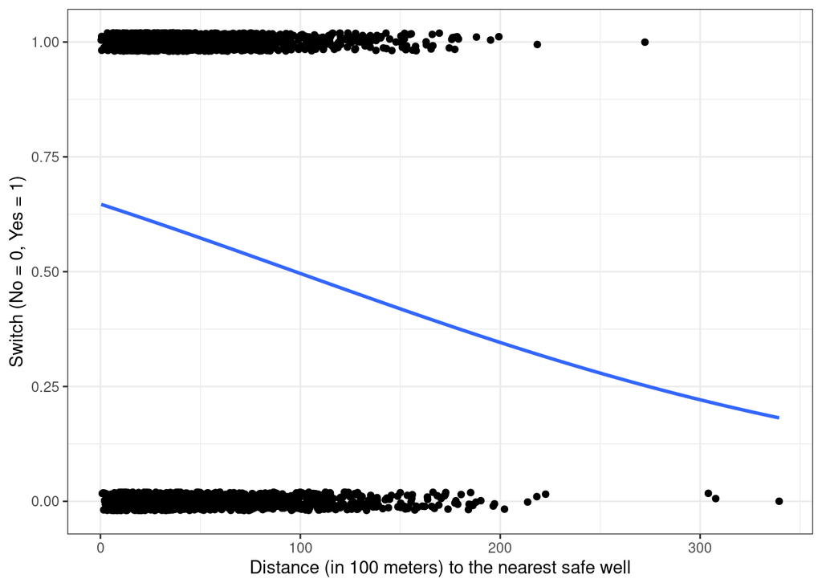

```r
ggplot(df,aes(x = distance, y = as.numeric(switch_well)-1)) +
  # jitter used to account for overlapping points
  geom_point(position = position_jitter(0,0.02)) +
  # creating line calculating y based on x
  geom_smooth(method="glm", method.args=list(family="binomial"), se=FALSE, formula = y ~ x) +
  labs(x = "Distance (in 100 meters) to the nearest safe well", y = "Switch (No = 0, Yes = 1)")
```

#### Plot each input numerical variable vs. switch_well

We want to investigate whether the probability of switching wells is a clear function of the input numerical variables.

$\rightarrow$ Make scatter plots of `switch_well` vs. each of the input numerical variables.

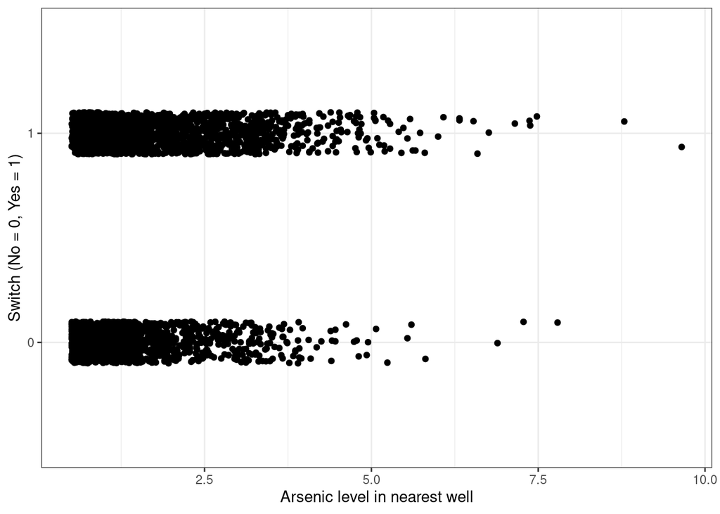

```r
# Plotting switch_well vs arsenic
df %>%
  ggplot(aes(x = arsenic, y = switch_well)) +
  geom_jitter(width = 0, height = 0.1) +
  labs(x = "Arsenic level in nearest well", y = "Switch (No = 0, Yes = 1)")
```

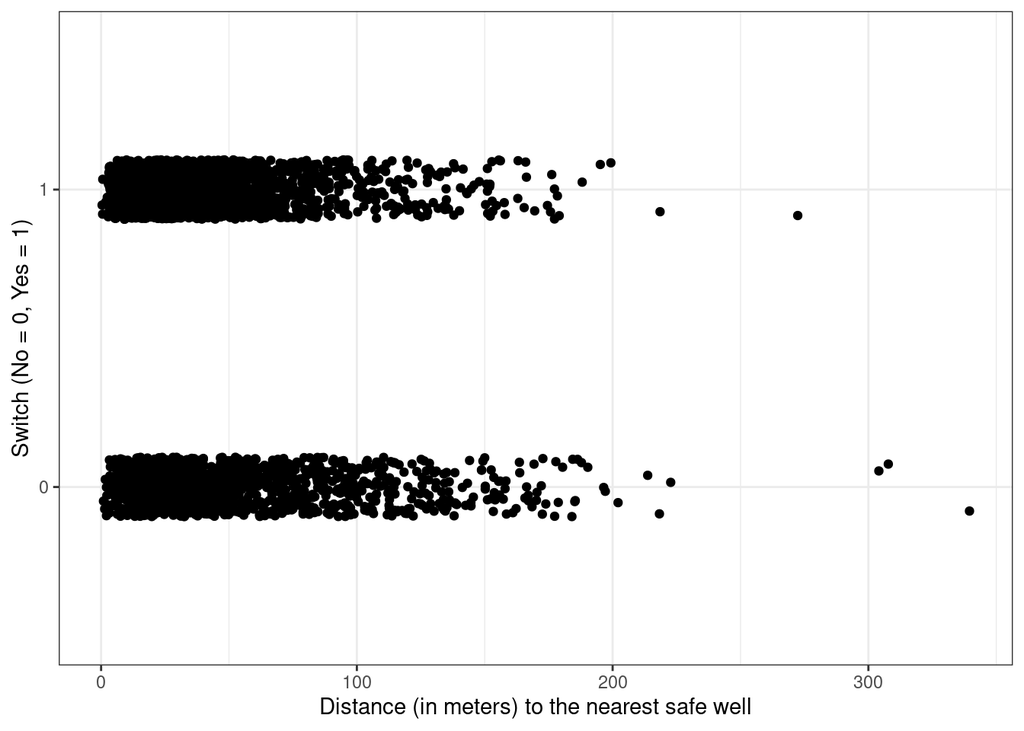

```r
# Plotting switch_well vs distance
df %>%
  ggplot(aes(x = distance, y = switch_well)) +
  geom_jitter(width = 0, height = 0.1) +
  labs(x = "Distance (in meters) to the nearest safe well", y = "Switch (No = 0, Yes = 1)")
```

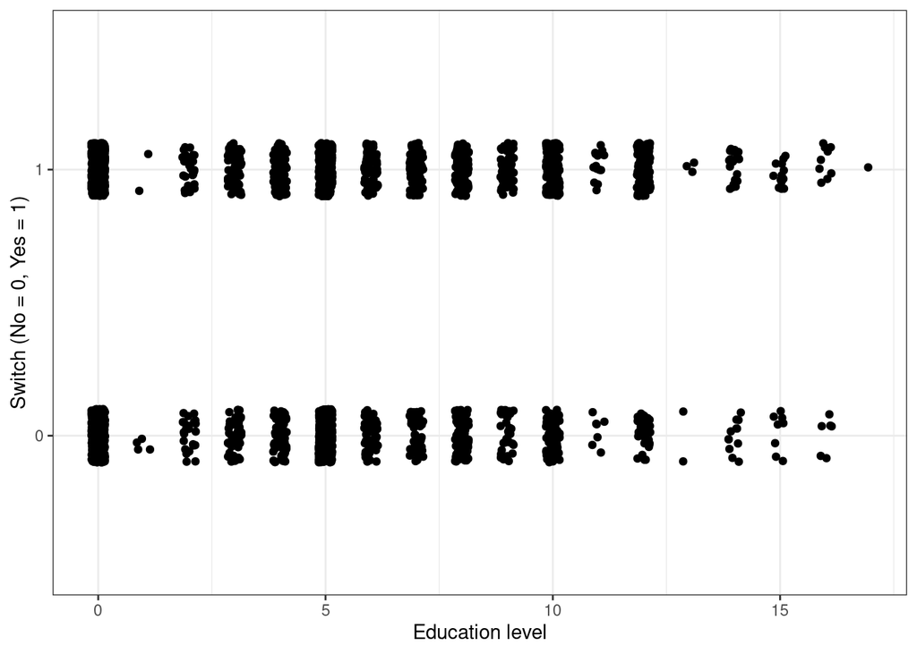

```r
# Plotting switch_well vs distance
df %>%
  ggplot(aes(x = education, y = switch_well)) +
  geom_jitter(width = 0.15, height = 0.1) +
  labs(x = "Education level", y = "Switch (No = 0, Yes = 1)")
```

#### Examine counts of categorical variable vs. switch_well

We want to investigate whether the probability of switching wells is a clear function of the input categorical variables `association`.

$\rightarrow$ Count the number of switches for each value of `association`. Additionally, calculate the proportion of switches for each value of `association`.

```r
# Viewing possible reslationship bewteen association and switch_well
df %>%
  group_by(association) %>%
  count(switch_well) %>%
  mutate(proportion = round(n/sum(n),2)) #I like to round so that we don't see too many decimal places
```

```
## # A tibble: 4 x 4
## # Groups:   association [2]
##   association switch_well     n proportion
##   <fct>       <fct>       <int>      <dbl>
## 1 0           0             714       0.41
## 2 0           1            1029       0.59
## 3 1           0             569       0.45
## 4 1           1             708       0.55
```

## Exploratory modeling

We will build logistic regression models of increasing complexity in order to further understand the data.

### Fit a model with distance as the predictor

$\rightarrow$ Before fitting, what sign do you expect for the coefficient on distance?

Negative because there is a negative relationship between distance and households using that well.

$\rightarrow$ Fit a logistic regression model with distance as the predictor and examine the summary.

```r
fit_dist <- logistic_reg() %>%
  set_engine("glm") %>%
  fit(switch_well ~ distance, data = df)
tidy(fit_dist)
```

```
## # A tibble: 2 x 5
##   term        estimate std.error statistic  p.value
##   <chr>          <dbl>     <dbl>     <dbl>    <dbl>
## 1 (Intercept)  0.606    0.0603       10.0  9.43e-24
## 2 distance    -0.00622  0.000974     -6.38 1.74e-10
```

It is difficult to interpret the coefficient on `distance` because distance is measured in meters. We don’t expect much of a change in switching behavior for wells that are 1 meter apart. A more natural measure is 100s of meters. We will scale the distance variable to be in units of 100s of meters.

$\rightarrow$ Use the `mutate` function to convert the distance units into 100s of meters.

```r
df <- df %>%
  # distance var now distance per 100m
  mutate(distance = distance/100)
```

$\rightarrow$ Refit the model and inspect the summary. How do you expect the coefficients to change?

```r
# fitting lostic regression model
fit_dist <- logistic_reg() %>%
  set_engine("glm") %>%
  fit(switch_well ~ distance, data = df)

tidy(fit_dist)
```

```
## # A tibble: 2 x 5
##   term        estimate std.error statistic  p.value
##   <chr>          <dbl>     <dbl>     <dbl>    <dbl>
## 1 (Intercept)    0.606    0.0603     10.0  9.43e-24
## 2 distance      -0.622    0.0974     -6.38 1.74e-10
```

$\rightarrow$ Plot the fitted logistic regression model:
$$P(\text{switch_well} = 1|\text{distance}) = \frac{1}{1 + e^{-(0.61 - 0.62 \times \text{distance})}}$$

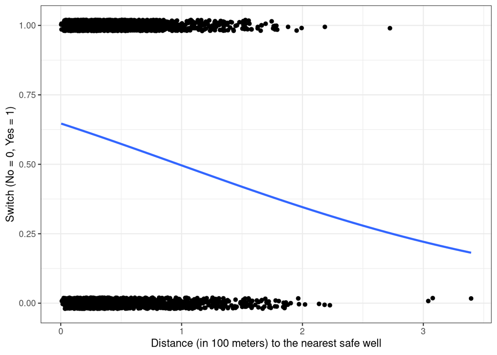

```r
# Plotting switch vs distance now using distance / 100m
ggplot(df,aes(x = distance, y = as.numeric(switch_well)-1)) +
  geom_point(position = position_jitter(0,0.02)) +
  geom_smooth(method="glm", method.args=list(family="binomial"), se=FALSE, formula = y ~ x) +
  labs(x = "Distance (in 100 meters) to the nearest safe well", y = "Switch (No = 0, Yes = 1)")
```

As distance increases, the probability that people will switch well decreases. Many people have not switched despite an increased distance.

#### Interpret the coefficients

$\rightarrow$ Interpret the value of $\hat{\beta}_0$.

This is the probability of switching at Distance being equal to 0: This value is about 0.65.

$\rightarrow$ Interpret the value of $\hat{\beta}_1$ by discussing its sign and what it says about the maximum rate of change of the probability of switching.

Beta 1 is negative meaning that there is negative relationship between distance to a well and switching well. Beta 1 / 4 = -0.1555, every 1 unit change in predictor, we expect a decrease in the probability of switching by about 16%.

### Fit a model with distance and arsenic as predictors

Fit the model and examine the coefficients.

```r
fit_dist_ars <- logistic_reg() %>%
  set_engine("glm") %>%
  fit(switch_well ~ distance + arsenic, data = df)
tidy(fit_dist_ars)
```

```
## # A tibble: 3 x 5
##   term        estimate std.error statistic  p.value
##   <chr>          <dbl>     <dbl>     <dbl>    <dbl>
## 1 (Intercept)  0.00275    0.0794    0.0346 9.72e- 1
## 2 distance    -0.897      0.104    -8.59   8.48e-18
## 3 arsenic      0.461      0.0414   11.1    8.58e-29
```

#### Explore the model

$\rightarrow$ Interpret the meaning of the coefficients.

As Arsenic increases in your current well, the more likely you are to switch

$\rightarrow$ Why did the coefficient for `distance` change when arsenic was added?

There is some relationship between arsenic and distance. This is why distance changed.

#### Visualize

Plot the decision boundary

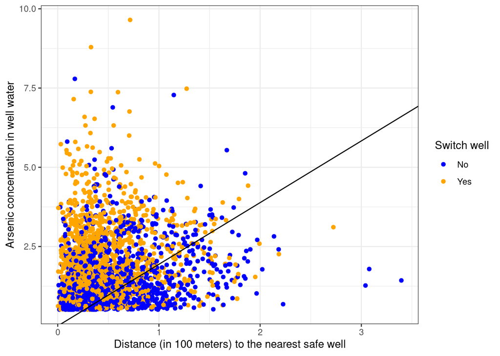

```r
#Give a shorter name for the coefficients to make it easier to read
betas <- fit_dist_ars$fit$coefficients

df %>%
  ggplot(aes(x = distance, y = arsenic, color = factor(switch_well))) +
  geom_point() +
  # plotting line using beta values and slope
  geom_abline(intercept = -betas[1]/betas[3], slope = -betas[2]/betas[3]) +
  labs(x = "Distance (in 100 meters) to the nearest safe well", y = "Arsenic concentration in well water", color = "Switch well") +
  scale_color_manual(labels = c("No", "Yes"), values = c("blue", "orange"))
```

Separation is not very clear, even after adding arsenic as a variable.

## Compare models

We will use logistic regression, XGBoost, and k-nearest neighbors to construct models that predict the probability of switching wells.

To compare the different approaches, we will use a training and testing split of the data set.

We will use the tidymodels approach for all models.

### Get train and test splits

We will split the data into training and testing sets, with 80% of the data kept for training.

```r
# Do the split. Keep 80% for training. Use stratified sampling based on switch_well to keep the proportion of switches in the test and training sets to be approximately equal.
set.seed(12)
split <- initial_split(df, prop = 0.8, strata = switch_well)

# Extract the training and testing splits
df_train <- training(split)
df_test <- testing(split)
```

### Null model

The null model prediction always predicts the value of `switch_well` that occurs most often in the training data.

$\rightarrow$ What is the null model prediction for `switch_well`?

```r
# Counting the amount that people switch wells in the training dataset
df_train %>%
  count(switch_well)
```

```
##   switch_well    n
## 1           0 1027
## 2           1 1390
```

If we always predict that a household will switch wells, how accurate is the prediction on test data?

About 57.5%

```r
# null_model predicts: switch_well == 1
# test our null models accuracy
null_accuracy <- sum(df_test$switch_well == 1)/length(df_test$switch_well)

null_accuracy %>% round(3)
```

```
## [1] 0.575
```

This represents a baseline that other models will be compared to.

### Modeling steps using tidymodels

Using tidymodels, we will take the same steps to modeling for each type of model that we use.

1. Specify a model (e.g. logistic_reg(), boost_tree()) and set an engine
2. Create a workflow that specifies the model formula to fit and the model type
3. Fit any hyperparameters
4. Fit the model to training data
5. Predict using test data
6. Assess the model

### Logistic regression model

#### Model specification

$\rightarrow$ First specify a logistic regression model with the glm engine.

```r
# Set up model spec for logistic regression
log_reg_model <- logistic_reg() %>%
  set_engine("glm")
```

#### Workflow

$\rightarrow$ Create a workflow that specifies the model formula to fit and add the model specification.

```r
# Set up workflow for logistic regression, start with full model
log_reg_wf <- workflow() %>%
  add_formula(switch_well ~ .) %>%
  add_model(log_reg_model)

log_reg_wf
```

```
## ══ Workflow ════════════════════════════════════════════════════════════════════
## Preprocessor: Formula
## Model: logistic_reg()
##
## ── Preprocessor ────────────────────────────────────────────────────────────────
## switch_well ~ .
##
## ── Model ───────────────────────────────────────────────────────────────────────
## Logistic Regression Model Specification (classification)
##
## Computational engine: glm
```

#### Fit to training data

Fit the model to the training data and explore the coefficients.

$\rightarrow$ First fit the model.

```r
# Fitting model
log_reg_fit <- log_reg_wf %>%
  fit(df_train)
```

$\rightarrow$ Examine the coefficients

```r
# Examining model
tidy(log_reg_fit)
```

```
## # A tibble: 5 x 5
##   term         estimate std.error statistic  p.value
##   <chr>           <dbl>     <dbl>     <dbl>    <dbl>
## 1 (Intercept)   -0.195     0.111      -1.76 7.88e- 2
## 2 arsenic        0.469     0.0464     10.1  4.67e-24
## 3 distance      -0.856     0.115      -7.43 1.11e-13
## 4 association1  -0.169     0.0861     -1.96 4.96e- 2
## 5 education      0.0483    0.0107      4.52 6.24e- 6
```

Potentially drop association from the model.

#### Predict test data

$\rightarrow$ Generate predictions and bind the predictions together with the true `switch_well` values from the test data.

```r
# Generating predictions
predictions_log_reg <- log_reg_fit %>%
  predict(new_data = df_test) %>%
  bind_cols(df_test %>% select(switch_well))
```

#### Assess fit

$\rightarrow$ Plot the confusion matrix.

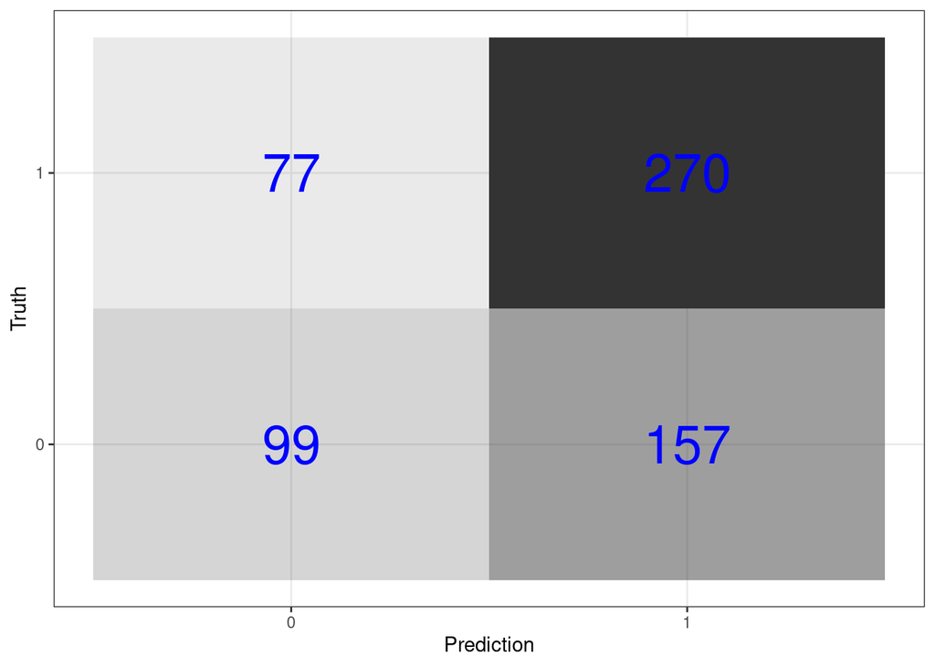

```r
# Plotting confusion matrix
predictions_log_reg %>%
  conf_mat(switch_well, .pred_class) %>%
  pluck(1) %>%
  as_tibble() %>%
  ggplot(aes(Prediction, Truth, alpha = n)) +
  geom_tile(show.legend = FALSE) +
  geom_text(aes(label = n), color = "blue", alpha = 1, size = 10)
```

We will further analyze the performance of the model quantitatively by computing the prediction accuracy, the sensitivity, and the specificity. You should first convince yourself that you can compute these quantities by hand from the confusion matrix.

$\rightarrow$ Get the prediction accuracy. This prediction accuracy is equal to the proportion of correct predictions in the test data set.

```r
# getting accuracy from predictions
log_reg_acc <- predictions_log_reg %>%
  metrics(switch_well, .pred_class) %>%
  select(-.estimator) %>%
  filter(.metric == "accuracy") %>%
  mutate(.estimate = round(.estimate,3))
```

$\rightarrow$ Compare to null model prediction

Better by about 4%. That isn’t very impressive at all.

$\rightarrow$ Get the sensitivity. This is the proportion of correct predictions for households that did switch wells.

```r
# Getting sensitivity from predictions
log_reg_sens <- predictions_log_reg %>%
  sens(switch_well, .pred_class, event_level = "second") %>%
  select(-.estimator) %>%
  mutate(.estimate = round(.estimate,3))
```

$\rightarrow$ Get the specificity. This is the proportion of correct predictions for households that did not switch wells.

```r
# Get specificity
log_reg_spec <- predictions_log_reg %>%
  spec(switch_well, .pred_class, event_level = "second") %>%
  select(-.estimator) %>%
  mutate(.estimate = round(.estimate,3))
```

There are people that aren’t switching and we can’t predict that well.

### XGBoost

#### Set up the model

The model will be a boosted tree model, so we start by specifying the features of a `boost_tree` model. The`boost_tree` creates a specification of a model, but does not fit the model.

$\rightarrow$ First specify an XGBoost model for classification with the xgboost engine. Set`tree_depth`, `min_n`, `loss_reduction`, `sample_size`, `mtry`, and `learn_rate` as parameters to tune. Set `trees` = 1000.

```r
xgb_model <- boost_tree(
  mode = "classification",  #We are solving a classification problem
  trees = 1000,
  tree_depth = tune(),  # tune() says that we will specify this parameter later
  min_n = tune(),
  loss_reduction = tune(),
  sample_size = tune(),
  mtry = tune(),
  learn_rate = tune(),
  ) %>%
  set_engine("xgboost") ## We will use xgboost to fit the model

xgb_model
```

```
## Boosted Tree Model Specification (classification)
##
## Main Arguments:
##   mtry = tune()
##   trees = 1000
##   min_n = tune()
##   tree_depth = tune()
##   learn_rate = tune()
##   loss_reduction = tune()
##   sample_size = tune()
##
## Computational engine: xgboost
```

$\rightarrow$ Create a workflow that specifies the model formula and the model type. We are still setting up the model; this does not fit the model.

```r
xgb_wf <- workflow() %>%
  add_formula(switch_well ~ .) %>%
  add_model(xgb_model)

xgb_wf
```

```
## ══ Workflow ════════════════════════════════════════════════════════════════════
## Preprocessor: Formula
## Model: boost_tree()
##
## ── Preprocessor ────────────────────────────────────────────────────────────────
## switch_well ~ .
##
## ── Model ───────────────────────────────────────────────────────────────────────
## Boosted Tree Model Specification (classification)
##
## Main Arguments:
##   mtry = tune()
##   trees = 1000
##   min_n = tune()
##   tree_depth = tune()
##   learn_rate = tune()
##   loss_reduction = tune()
##   sample_size = tune()
##
## Computational engine: xgboost
```

#### Fit the model

We need to fit all of the parameters that we specified as `tune()`.

$\rightarrow$ Specify the parameter grid using the function `grid_latin_hypercube`:

```r
xgb_grid <- grid_latin_hypercube(
  tree_depth(),
  min_n(),
  loss_reduction(),
  sample_size = sample_prop(),
  finalize(mtry(), df_train),
  learn_rate(),
  size = 30  #Create 30 sets of the 6 parameters
)
```

$\rightarrow$ Create folds for cross-validation, using stratified sampling based on `switch_well`.

```r
# Folds for cv
folds <- vfold_cv(df_train, strata = switch_well)
```

$\rightarrow$ Do the parameter fitting.

```r
xgb_grid_search <- tune_grid(
  xgb_wf,              #The workflow
  resamples = folds,   #The training data split into folds
  grid = xgb_grid,     #The grid of parameters to fit
  control = control_grid(save_pred = TRUE)
)

xgb_grid_search
```

```
## # Tuning results
## # 10-fold cross-validation using stratification
## # A tibble: 10 x 5
##    splits         id     .metrics          .notes          .predictions
##    <list>         <chr>  <list>            <list>          <list>
##  1 <split [2175/… Fold01 <tibble[,10] [60… <tibble[,1] [0… <tibble[,12] [7,260 …
##  2 <split [2175/… Fold02 <tibble[,10] [60… <tibble[,1] [0… <tibble[,12] [7,260 …
##  3 <split [2175/… Fold03 <tibble[,10] [60… <tibble[,1] [0… <tibble[,12] [7,260 …
##  4 <split [2175/… Fold04 <tibble[,10] [60… <tibble[,1] [0… <tibble[,12] [7,260 …
##  5 <split [2175/… Fold05 <tibble[,10] [60… <tibble[,1] [0… <tibble[,12] [7,260 …
##  6 <split [2175/… Fold06 <tibble[,10] [60… <tibble[,1] [0… <tibble[,12] [7,260 …
##  7 <split [2175/… Fold07 <tibble[,10] [60… <tibble[,1] [0… <tibble[,12] [7,260 …
##  8 <split [2176/… Fold08 <tibble[,10] [60… <tibble[,1] [0… <tibble[,12] [7,230 …
##  9 <split [2176/… Fold09 <tibble[,10] [60… <tibble[,1] [0… <tibble[,12] [7,230 …
## 10 <split [2176/… Fold10 <tibble[,10] [60… <tibble[,1] [0… <tibble[,12] [7,230 …
```

$\rightarrow$ Get the best model based on `accuracy`.

```r
# finding best model
best_xgb <- select_best(xgb_grid_search, "accuracy")
```

$\rightarrow$ Update the workflow with the best parameters.

```r
final_xgb <- finalize_workflow(
  xgb_wf,
  best_xgb
)

final_xgb
```

```
## ══ Workflow ════════════════════════════════════════════════════════════════════
## Preprocessor: Formula
## Model: boost_tree()
##
## ── Preprocessor ────────────────────────────────────────────────────────────────
## switch_well ~ .
##
## ── Model ───────────────────────────────────────────────────────────────────────
## Boosted Tree Model Specification (classification)
##
## Main Arguments:
##   mtry = 4
##   trees = 1000
##   min_n = 8
##   tree_depth = 15
##   learn_rate = 0.00231700171595376
##   loss_reduction = 0.49323820266506
##   sample_size = 0.182168259744067
##
## Computational engine: xgboost
```

#### Fit to training data

$\rightarrow$ Fit the model to the training data.

```r
# Fitting best model
xgb_fit <- final_xgb %>%
  fit(df_train)
```

```
## [17:53:50] WARNING: amalgamation/../src/learner.cc:1061: Starting in XGBoost 1.3.0, the default evaluation metric used with the objective 'binary:logistic' was changed from 'error' to 'logloss'. Explicitly set eval_metric if you'd like to restore the old behavior.
```

#### Predict test data

$\rightarrow$ Generate predictions and bind them together with the true values from the test data.

```r
# Generating predictions
predictions_xgb <- xgb_fit %>%
  predict(new_data = df_test) %>%
  bind_cols(df_test %>% select(switch_well))
```

#### Assess fit

$\rightarrow$ Plot the confusion matrix

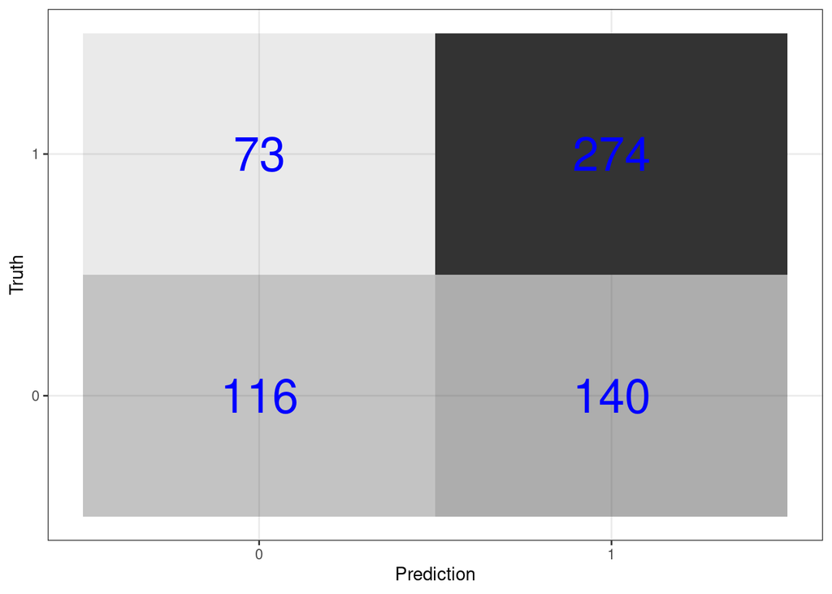

```r
# Plotting confusion matrix
predictions_xgb %>%
  conf_mat(switch_well, .pred_class) %>%
  pluck(1) %>%
  as_tibble() %>%
  ggplot(aes(Prediction, Truth, alpha = n)) +
  geom_tile(show.legend = FALSE) +
  geom_text(aes(label = n), color = "blue", alpha = 1, size = 10)
```

$\rightarrow$ Get prediction accuracy. This prediction accuracy is equal to the proportion of correct predictions in the test data set.

Accuracy = Correct predictions / all predictions

```r
# Getting accuracy from predictions
xgb_acc <- predictions_xgb %>%
  metrics(switch_well, .pred_class) %>%
  select(-.estimator) %>%
  filter(.metric == "accuracy") %>%
  mutate(.estimate = round(.estimate,3))
```

$\rightarrow$ Compare to null model prediction

```r
null_accuracy %>% round(3)
```

```
## [1] 0.575
```

$\rightarrow$ Get the sensitivity. This is the proportion of correct predictions for households that did switch wells.

```r
# Getting sensitivity from predictions
xgb_sens <- predictions_xgb %>%
  sens(switch_well, .pred_class, event_level = "second") %>%
  select(-.estimator) %>%
  mutate(.estimate = round(.estimate,3))
```

$\rightarrow$ Get the specificity. This is the proportion of correct predictions for households that did not switch wells.

```r
# Getting specificity from predictions
xgb_spec <- predictions_xgb %>%
  spec(switch_well, .pred_class, event_level = "second") %>%
  select(-.estimator) %>%
  mutate(.estimate = round(.estimate,3))
```

#### Relative importance of predictors

$\rightarrow$ Look at which predictors are most important in the model

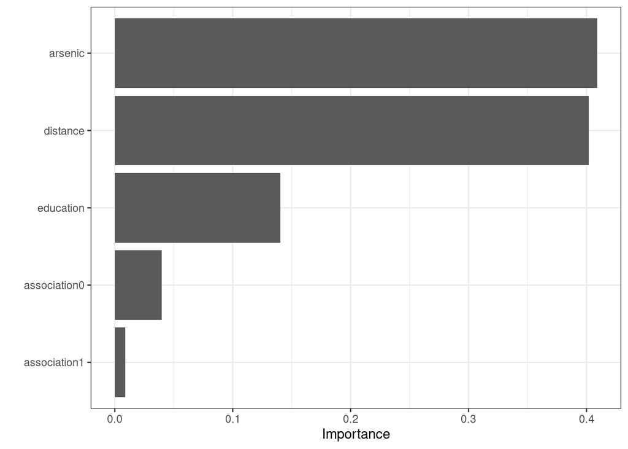

```r
# viewing xgb predictor importance
xgb_fit %>%
  pull_workflow_fit() %>%
  vip(geom = "col")
```

### k nearest neighbors

#### Model specification

First specify a k nearest neighbors model with the kknn engine.

```r
 # Setting up knn model
knn_model <- nearest_neighbor(
    mode = "classification",
    neighbors = tune("K")
  ) %>%
  set_engine("kknn")
```

#### Workflow

Create a workflow that specifies the model formula to fit and the model type.

```r
# Creating knn workflow
knn_wf <- workflow() %>%
  add_formula(switch_well ~ .) %>%
  add_model(knn_model)
```

#### Fit the hyperparameter k

Specify a set of values of k to try.

```r
# Finding best ks to try
knn_grid <- parameters(knn_wf) %>%
  update(K = neighbors(c(1, 50))) %>%
  grid_latin_hypercube(size = 10)

knn_grid
```

```
## # A tibble: 10 x 1
##        K
##    <int>
##  1    16
##  2    30
##  3    39
##  4    22
##  5    10
##  6    49
##  7    41
##  8    12
##  9    33
## 10     2
```

Use cross validation on the previously defined folds to find the best value of k.

```r
# Finding best k
knn_grid_search <- tune_grid(
  knn_wf,
  resamples = folds,
  grid = knn_grid,
  control = control_grid(save_pred = TRUE)
)

knn_grid_search
```

```
## # Tuning results
## # 10-fold cross-validation using stratification
## # A tibble: 10 x 5
##    splits          id     .metrics          .notes          .predictions
##    <list>          <chr>  <list>            <list>          <list>
##  1 <split [2175/2… Fold01 <tibble[,5] [20 … <tibble[,1] [0… <tibble[,7] [2,420 …
##  2 <split [2175/2… Fold02 <tibble[,5] [20 … <tibble[,1] [0… <tibble[,7] [2,420 …
##  3 <split [2175/2… Fold03 <tibble[,5] [20 … <tibble[,1] [0… <tibble[,7] [2,420 …
##  4 <split [2175/2… Fold04 <tibble[,5] [20 … <tibble[,1] [0… <tibble[,7] [2,420 …
##  5 <split [2175/2… Fold05 <tibble[,5] [20 … <tibble[,1] [0… <tibble[,7] [2,420 …
##  6 <split [2175/2… Fold06 <tibble[,5] [20 … <tibble[,1] [0… <tibble[,7] [2,420 …
##  7 <split [2175/2… Fold07 <tibble[,5] [20 … <tibble[,1] [0… <tibble[,7] [2,420 …
##  8 <split [2176/2… Fold08 <tibble[,5] [20 … <tibble[,1] [0… <tibble[,7] [2,410 …
##  9 <split [2176/2… Fold09 <tibble[,5] [20 … <tibble[,1] [0… <tibble[,7] [2,410 …
## 10 <split [2176/2… Fold10 <tibble[,5] [20 … <tibble[,1] [0… <tibble[,7] [2,410 …
```

Get the best model based on `accuracy`.

```r
# Getting k that optimized accuracy
best_knn <- select_best(knn_grid_search, "accuracy")
```

Update the workflow with the best parameter k.

```r
# updating workflow with best k
final_knn <- finalize_workflow(
  knn_wf,
  best_knn
)

final_knn
```

```
## ══ Workflow ════════════════════════════════════════════════════════════════════
## Preprocessor: Formula
## Model: nearest_neighbor()
##
## ── Preprocessor ────────────────────────────────────────────────────────────────
## switch_well ~ .
##
## ── Model ───────────────────────────────────────────────────────────────────────
## K-Nearest Neighbor Model Specification (classification)
##
## Main Arguments:
##   neighbors = 49
##
## Computational engine: kknn
```

#### Fit to training data

Fit the model to the training data and explore the coefficients.

First fit the model.

```r
# Fitting knn model
knn_fit <- final_knn %>%
  fit(df_train)
```

#### Predict test data

Generate predictions and bind together with the true values from the test data.

```r
# predicting using knn model
predictions_knn <- knn_fit %>%
  predict(new_data = df_test) %>%
  bind_cols(df_test %>% select(switch_well))
```

#### Assess fit

Visualize the confusion matrix

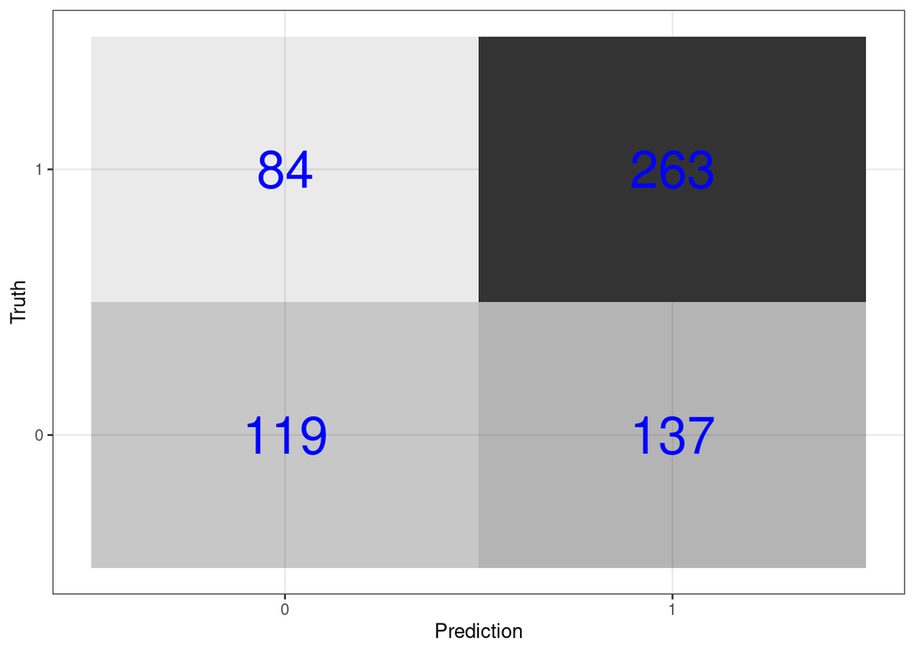

```r
# Creating confusion matrix
predictions_knn %>%
  conf_mat(switch_well, .pred_class) %>%
  pluck(1) %>%
  as_tibble() %>%
  ggplot(aes(Prediction, Truth, alpha = n)) +
  geom_tile(show.legend = FALSE) +
  geom_text(aes(label = n), color = "blue", alpha = 1, size = 10)
```

Get prediction accuracy. This prediction accuracy is equal to the proportion of correct predictions in the test data set.

```r
# getting knn accuracy
knn_acc <- predictions_knn %>%
  metrics(switch_well, .pred_class) %>%
  select(-.estimator) %>%
  filter(.metric == "accuracy") %>%
  mutate(.estimate = round(.estimate,3))
```

Compare to null model prediction

The null model is accurate

```r
null_accuracy %>% round(3)
```

```
## [1] 0.575
```

percent of the time.

Get the sensitivity. This is the proportion of correct predictions for households that did switch wells.

```r
# Getting knn sensitivity
knn_sens <- predictions_knn %>%
  sens(switch_well, .pred_class, event_level = "second") %>%
  select(-.estimator) %>%
  mutate(.estimate = round(.estimate,3))
```

Get the specificity. This is the proportion of correct predictions for households that did not switch wells.

```r
# Getting knn specificity
knn_spec <- predictions_knn %>%
  spec(switch_well, .pred_class, event_level = "second") %>%
  select(-.estimator) %>%
  mutate(.estimate = round(.estimate,3))
```

### Compare models

You used three methods to construct a model

1. Logistic regression
2. XGBoost
3. k nearest neighbors

Compare the performance of the models.

#### Accuracy

```r
print(paste('null accuracy:',null_accuracy))
```

```
## [1] "null accuracy: 0.575456053067993"
```

```r
print(paste('logisitc regression accuracy:',log_reg_acc$.estimate))
```

```
## [1] "logisitc regression accuracy: 0.612"
```

```r
print(paste('XGBoost accuracy:',xgb_acc$.estimate))
```

```
## [1] "XGBoost accuracy: 0.647"
```

```r
print(paste('knn accuracy:',knn_acc$.estimate))
```

```
## [1] "knn accuracy: 0.633"
```

#### Sensitivity

```r
print(paste('logisitc regression sensitivity:',log_reg_sens$.estimate))
```

```
## [1] "logisitc regression sensitivity: 0.778"
```

```r
print(paste('XGBoost sensitivity:',xgb_sens$.estimate))
```

```
## [1] "XGBoost sensitivity: 0.79"
```

```r
print(paste('knn sensitivity:',knn_sens$.estimate))
```

```
## [1] "knn sensitivity: 0.758"
```

#### Specificity

```r
print(paste('logisitc regression specificity:',log_reg_spec$.estimate))
```

```
## [1] "logisitc regression specificity: 0.387"
```

```r
print(paste('XGBoost specificity',xgb_spec$.estimate))
```

```
## [1] "XGBoost specificity 0.453"
```

```r
print(paste('knn specificity',knn_spec$.estimate))
```

```
## [1] "knn specificity 0.465"
```

## Additional step

While our best model according to accuracy and sensitivity was XGBoost, I wonder how much better it would be if we remove the association variables as those variables seem to not contribute much to our model.

#### Set up the model

The model will be a boosted tree model, so we start by specifying the features of a `boost_tree` model. The`boost_tree` creates a specification of a model, but does not fit the model.

$\rightarrow$ First specify an XGBoost model for classification with the xgboost engine. Set`tree_depth`, `min_n`, `loss_reduction`, `sample_size`, `mtry`, and `learn_rate` as parameters to tune. Set `trees` = 1000.

```r
xgb_model <- boost_tree(
  mode = "classification",  #We are solving a classification problem
  trees = 1000,
  tree_depth = tune(),  # tune() says that we will specify this parameter later
  min_n = tune(),
  loss_reduction = tune(),
  sample_size = tune(),
  mtry = tune(),
  learn_rate = tune(),
  ) %>%
  set_engine("xgboost") ## We will use xgboost to fit the model

xgb_model
```

```
## Boosted Tree Model Specification (classification)
##
## Main Arguments:
##   mtry = tune()
##   trees = 1000
##   min_n = tune()
##   tree_depth = tune()
##   learn_rate = tune()
##   loss_reduction = tune()
##   sample_size = tune()
##
## Computational engine: xgboost
```

$\rightarrow$ Create a workflow that specifies the model formula and the model type. We are still setting up the model; this does not fit the model.

```r
xgb_wf <- workflow() %>%
  add_formula(switch_well ~ distance + arsenic + education) %>%
  add_model(xgb_model)

xgb_wf
```

```
## ══ Workflow ════════════════════════════════════════════════════════════════════
## Preprocessor: Formula
## Model: boost_tree()
##
## ── Preprocessor ────────────────────────────────────────────────────────────────
## switch_well ~ distance + arsenic + education
##
## ── Model ───────────────────────────────────────────────────────────────────────
## Boosted Tree Model Specification (classification)
##
## Main Arguments:
##   mtry = tune()
##   trees = 1000
##   min_n = tune()
##   tree_depth = tune()
##   learn_rate = tune()
##   loss_reduction = tune()
##   sample_size = tune()
##
## Computational engine: xgboost
```

#### Fit the model

We need to fit all of the parameters that we specified as `tune()`.

$\rightarrow$ Specify the parameter grid using the function `grid_latin_hypercube`:

```r
xgb_grid <- grid_latin_hypercube(
  tree_depth(),
  min_n(),
  loss_reduction(),
  sample_size = sample_prop(),
  finalize(mtry(), df_train),
  learn_rate(),
  size = 30  #Create 30 sets of the 6 parameters
)
```

$\rightarrow$ Create folds for cross-validation, using stratified sampling based on `switch_well`.

```r
# Folds for cv
folds <- vfold_cv(df_train, strata = switch_well)
```

$\rightarrow$ Do the parameter fitting.

```r
xgb_grid_search <- tune_grid(
  xgb_wf,              #The workflow
  resamples = folds,   #The training data split into folds
  grid = xgb_grid,     #The grid of parameters to fit
  control = control_grid(save_pred = TRUE)
)

xgb_grid_search
```

```
## # Tuning results
## # 10-fold cross-validation using stratification
## # A tibble: 10 x 5
##    splits         id     .metrics          .notes          .predictions
##    <list>         <chr>  <list>            <list>          <list>
##  1 <split [2175/… Fold01 <tibble[,10] [60… <tibble[,1] [0… <tibble[,12] [7,260 …
##  2 <split [2175/… Fold02 <tibble[,10] [60… <tibble[,1] [0… <tibble[,12] [7,260 …
##  3 <split [2175/… Fold03 <tibble[,10] [60… <tibble[,1] [0… <tibble[,12] [7,260 …
##  4 <split [2175/… Fold04 <tibble[,10] [60… <tibble[,1] [0… <tibble[,12] [7,260 …
##  5 <split [2175/… Fold05 <tibble[,10] [60… <tibble[,1] [0… <tibble[,12] [7,260 …
##  6 <split [2175/… Fold06 <tibble[,10] [60… <tibble[,1] [0… <tibble[,12] [7,260 …
##  7 <split [2175/… Fold07 <tibble[,10] [60… <tibble[,1] [0… <tibble[,12] [7,260 …
##  8 <split [2176/… Fold08 <tibble[,10] [60… <tibble[,1] [0… <tibble[,12] [7,230 …
##  9 <split [2176/… Fold09 <tibble[,10] [60… <tibble[,1] [0… <tibble[,12] [7,230 …
## 10 <split [2176/… Fold10 <tibble[,10] [60… <tibble[,1] [0… <tibble[,12] [7,230 …
```

$\rightarrow$ Get the best model based on `accuracy`.

```r
# finding best model
best_xgb <- select_best(xgb_grid_search, "accuracy")
```

$\rightarrow$ Update the workflow with the best parameters.

```r
final_xgb <- finalize_workflow(
  xgb_wf,
  best_xgb
)

final_xgb
```

```
## ══ Workflow ════════════════════════════════════════════════════════════════════
## Preprocessor: Formula
## Model: boost_tree()
##
## ── Preprocessor ────────────────────────────────────────────────────────────────
## switch_well ~ distance + arsenic + education
##
## ── Model ───────────────────────────────────────────────────────────────────────
## Boosted Tree Model Specification (classification)
##
## Main Arguments:
##   mtry = 4
##   trees = 1000
##   min_n = 27
##   tree_depth = 10
##   learn_rate = 0.00181499390806814
##   loss_reduction = 2.76232103055762e-06
##   sample_size = 0.600540785268527
##
## Computational engine: xgboost
```

#### Fit to training data

$\rightarrow$ Fit the model to the training data.

```r
# Fitting best model
xgb_fit <- final_xgb %>%
  fit(df_train)
```

```
## [18:04:47] WARNING: amalgamation/../src/learner.cc:1061: Starting in XGBoost 1.3.0, the default evaluation metric used with the objective 'binary:logistic' was changed from 'error' to 'logloss'. Explicitly set eval_metric if you'd like to restore the old behavior.
```

#### Predict test data

$\rightarrow$ Generate predictions and bind them together with the true values from the test data.

```r
# Generating predictions
predictions_xgb <- xgb_fit %>%
  predict(new_data = df_test) %>%
  bind_cols(df_test %>% select(switch_well))
```

#### Assess fit

$\rightarrow$ Plot the confusion matrix

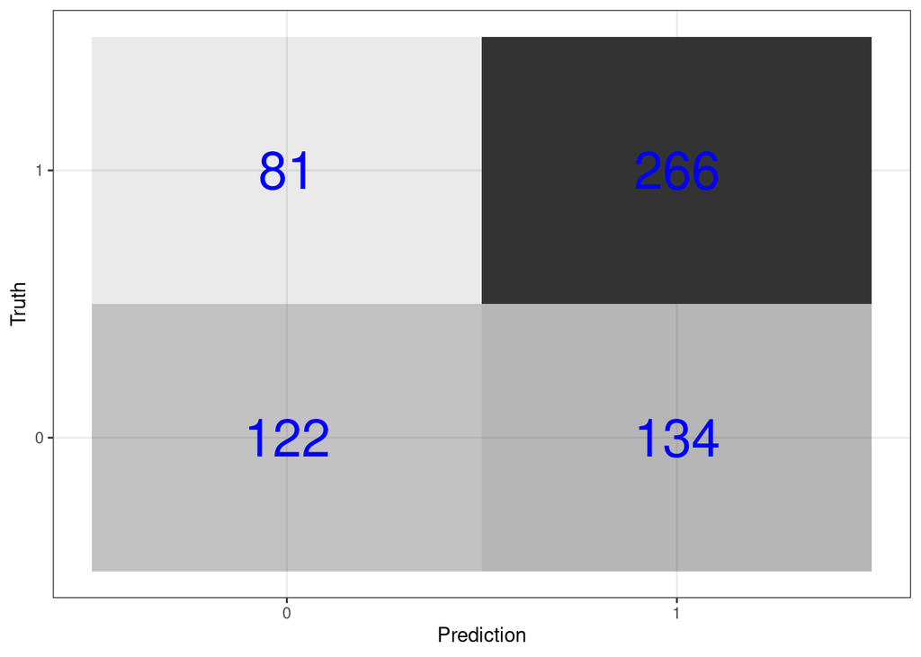

```r
# Plotting confusion matrix
predictions_xgb %>%
  conf_mat(switch_well, .pred_class) %>%
  pluck(1) %>%
  as_tibble() %>%
  ggplot(aes(Prediction, Truth, alpha = n)) +
  geom_tile(show.legend = FALSE) +
  geom_text(aes(label = n), color = "blue", alpha = 1, size = 10)
```

$\rightarrow$ Get prediction accuracy. This prediction accuracy is equal to the proportion of correct predictions in the test data set.

Accuracy = Correct predictions / all predictions

```r
# Getting accuracy from predictions
xgb_acc <- predictions_xgb %>%
  metrics(switch_well, .pred_class) %>%
  select(-.estimator) %>%
  filter(.metric == "accuracy") %>%
  mutate(.estimate = round(.estimate,3))
xgb_acc
```

```
## # A tibble: 1 x 2
##   .metric  .estimate
##   <chr>        <dbl>
## 1 accuracy     0.643
```

$\rightarrow$ Get the sensitivity. This is the proportion of correct predictions for households that did switch wells.

```r
# Getting sensitivity from predictions
xgb_sens <- predictions_xgb %>%
  sens(switch_well, .pred_class, event_level = "second") %>%
  select(-.estimator) %>%
  mutate(.estimate = round(.estimate,3))
xgb_sens
```

```
## # A tibble: 1 x 2
##   .metric .estimate
##   <chr>       <dbl>
## 1 sens        0.767
```

$\rightarrow$ Get the specificity. This is the proportion of correct predictions for households that did not switch wells.

```r
# Getting specificity from predictions
xgb_spec <- predictions_xgb %>%
  spec(switch_well, .pred_class, event_level = "second") %>%
  select(-.estimator) %>%
  mutate(.estimate = round(.estimate,3))

xgb_spec
```

```
## # A tibble: 1 x 2
##   .metric .estimate
##   <chr>       <dbl>
## 1 spec        0.477
```

#### Relative importance of predictors

$\rightarrow$ Look at which predictors are most important in the model

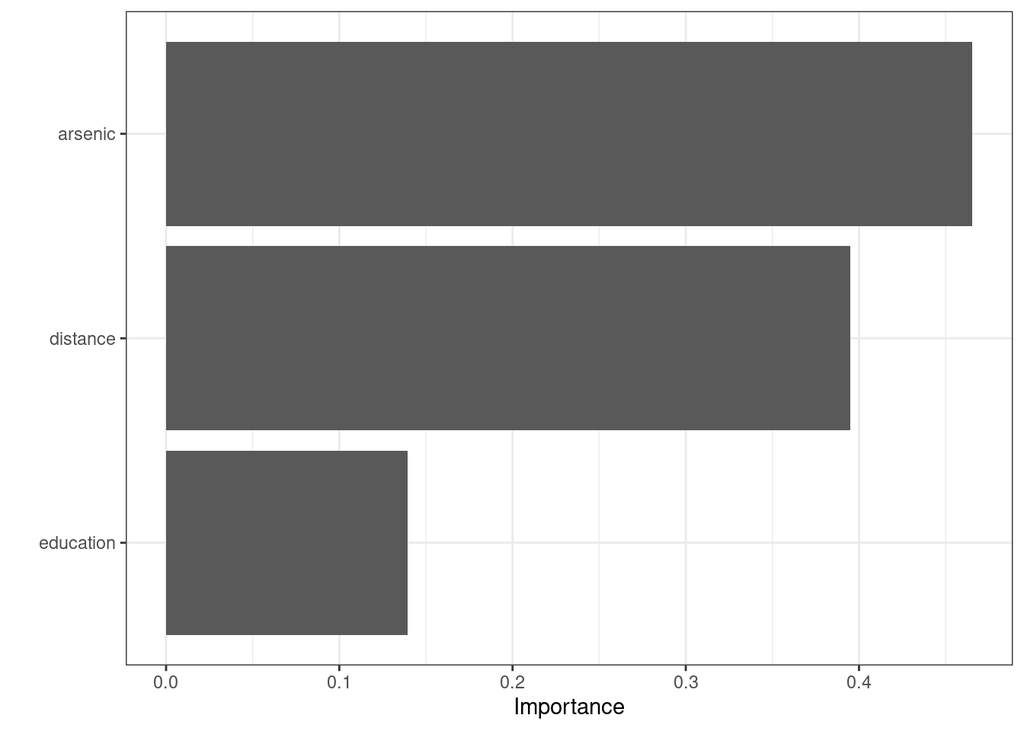

```r
# viewing xgb predictor importance
xgb_fit %>%
  pull_workflow_fit() %>%
  vip(geom = "col")
```

## Conclusion

After competing our analysis on the data, I conclude that while we can indeed create a model that predicts the odds of a household switching wells, it is just a little more accurate then the null model at roughly 60 to 65% despite trying different models. This is a very complex problem and I believe that in order to create better models we either need more samples of the same data or different types of variables that may be more indicative of a household switching wells. Certain factors I can think of off the top of my head are: Household size, a households transportation options, whether a household built their own well or not.